# KJurek_Livesession4assignment

Karl J. Jurek

December 3, 2018

## Question 1 Harry Potter Cast (50%)

## Question 1A:

In the IMDB, there are listings of full cast members for movies. Navigate to http://www.imdb.com/title/tt1201607/fullcredits?ref_=tt_ql_1. Feel free to View Source to get a good idea of what the page looks like in code.

```r
# Parsing of HTML/XML files
library(rvest)
# General-purpose data wrangling
library(tidyverse)
# String manipulation
library(stringr)
# Verbose regular expressions
library(rebus)
```

```r
# Creation of graphics
library(ggplot2)
# Data manipulation
library(dplyr)
# Time data manipulation
library(xts)
# Piping notation
library(magrittr)
```

## Question 1B:

Scrape the page with any R package that makes things easy for you. Of particular interest is the table of the Cast in order of crediting. Please scrape this table (you might have to fish it out of several of the tables from the page) and make it a data.frame() of the Cast in your R environment

```r
# Setting the website we are going to be gathering data from
URL="http://www.imdb.com/title/tt1201607/fullcredits?ref_=tt_ql_1"
# Getting the HTML from the website
hp_html=read_html(URL, options="NOBLANKS")
# Placing just the tables into 'hp_table'
hp_table=hp_html %>% html_nodes("table") %>% html_table()
# Putting just the cast data into a data frame
cast_df=as.data.frame(hp_table[3])
# Validating the desired results
head(cast_df)
```

```
##   X1               X2  X3                         X4
## 1
## 2       Ralph Fiennes ...             Lord Voldemort
## 3      Michael Gambon ... Professor Albus Dumbledore
## 4        Alan Rickman ...    Professor Severus Snape
## 5    Daniel Radcliffe ...               Harry Potter
## 6        Rupert Grint ...                Ron Weasley
```

## Question 1C: Clean up the table

### Question 1C-1:

It should not have blank observations or rows, a row that should be column names, or just ‘…’

```r
# Removing unnecessary columns from the data frame
cast_df=cast_df[-c(1,3)]
# Validating the desired results
cast_df[c(11, 34, 93),]
```

```
##                                     X2
## 11                       Warwick Davis
## 34                        Alfred Enoch
## 93 Rest of cast listed alphabetically:
##                                                     X4
## 11 Griphook /  \n            Professor Filius Flitwick
## 34            Dean Thomas \n  \n  \n  (as Alfie Enoch)
## 93                 Rest of cast listed alphabetically:
```

### Question 1C-2:

It should have intuitive column names (ideally 2 to start – Actor and Character)

```r
# Giving the columns in the data frame useful names
names(cast_df)<-c("Actor", "Character")
# Validating the desired results
cast_df[c(11, 34, 93),]
```

```
##                                  Actor
## 11                       Warwick Davis
## 34                        Alfred Enoch
## 93 Rest of cast listed alphabetically:
##                                              Character
## 11 Griphook /  \n            Professor Filius Flitwick
## 34            Dean Thomas \n  \n  \n  (as Alfie Enoch)
## 93                 Rest of cast listed alphabetically:
```

### Question 1C-3:

In the film, Mr. Warwick plays two characters, which makes his row look a little weird. Please replace his character column with just “Griphook / Professor Filius Flitwick” to make it look better.

```r
# Removing unnecessary 'next line' indicators
cast_df$Character=gsub("\r?\n|\r", "", cast_df$Character)
# Removing the extra spacing specifically in row 11
cast_df$Character=gsub("            ", "", cast_df$Character)
# Removing extra spacing through the 'Character' column
cast_df$Character=gsub("  ", "", cast_df$Character)
# Validating the desired results
cast_df[c(11, 34, 93),]
```

```
##                                  Actor                           Character
## 11                       Warwick Davis Griphook /Professor Filius Flitwick
## 34                        Alfred Enoch        Dean Thomas (as Alfie Enoch)
## 93 Rest of cast listed alphabetically: Rest of cast listed alphabetically:
```

### Question 1C-4:

One row might result in “Rest of cast listed alphabetically” – remove this observation.

```r
cast_df=cast_df[-c(93), ]
# Validating the desired results
cast_df[c(11, 34, 93),]
```

```
##            Actor                                 Character
## 11 Warwick Davis       Griphook /Professor Filius Flitwick
## 34  Alfred Enoch              Dean Thomas (as Alfie Enoch)
## 94  Jon Campling Death Eater in Gringotts (scenes deleted)
```

## Question 1D:

Split the Actor’s name into two columns: FirstName and Surname. Keep in mind that some actors/actresses have middle names as well. Please make sure that the middle names are in the FirstName column, in addition to the first name (example: given the Actor Frank Jeffrey Stevenson, the FirstName column would say “Frank Jeffrey.”)

```r
# Removing empty first row
cast_df=cast_df[-c(1),]
# Extracting all but the surname from the 'Actor' column
FNames=as.data.frame(unlist(str_extract_all(cast_df$Actor, ".*[^a-zA-Z]+")))
# Extracting all surname from the 'Actor' column
Surnames=as.data.frame(word(cast_df$Actor, -1))
# Placing the first names, surnames, and character in a new data field
new_cast_df=cbind(FNames, Surnames, cast_df$Character)
# Giving the columns in the data frame useful names
names(new_cast_df)=c("FName", "Surname", "Character")
# Validating the desired results
new_cast_df[c(1, 12, 81),]
```

```
##                       FName Surname           Character
## 1                    Ralph  Fiennes      Lord Voldemort
## 12           Helena Bonham   Carter Bellatrix Lestrange
## 81 Bob Yves Van Hellenberg    Hubar         Death Eater
```

## Question 1 SportsBall (50%)

## Question 2A:

On the ESPN website, there are statistics of each NBA player. Navigate to the San Antonio Spurs current statistics (likely http://www.espn.com/nba/team/stats/_/name/sa/san-antonio-spurs). You are interested in the Shooting Statistics table.

```r
# Setting the website we are going to be gathering data from
URL="http://www.espn.com/nba/team/stats/_/name/sa/san-antonio-spurs"
```

## Question 2B:

Scrape the page with any R package that makes things easy for you. There are a few tables on the page, so make sure you are targeting specifically the Shooting Statistics table.

```r
# Getting the HTML from the website
sa_html=read_html(URL, options="NOBLANKS")
# Placing just the tables into 'sa_table'
sa_table=sa_html %>% html_nodes("table") %>% html_table()
```

## Question 2C:

Clean up the table (You might get some warnings if you’re working with tibbles)

## Question 2C-1:

You’ll want to create an R data.frame() with one observation for each player. Make sure that you do not accidentally include blank rows, a row of column names, or the Totals row in the table as observations.

```r
# Putting just the 'Shooting Statistics' data into a data frame
ss_df=as.data.frame(sa_table[2])
# Removing non-data first and second rows, and the last row 'Totals'
ss_df=ss_df[-c(1:2, 17),]
# Creating a variable to hold the column names for the 'ss_df' data frame
col_names=c("Player", "FGM", "FGA", "FG%", "3PM", "3PA", "3P%", "FTM", "FTA", "FT%", "2PM", "2PA", "2P%", "PPS", "AFG%")
# Adding the column names to the 'ss_df' data frame
names(ss_df)=col_names
# Validating results
head(ss_df, 3)
```

```
##                  Player FGM  FGA  FG% 3PM 3PA  3P% FTM FTA  FT% 2PM  2PA
## 3     DeMar DeRozan, SG 9.2 19.1 .482 0.3 1.4 .182 5.6 6.5 0.86 8.9 17.7
## 4 LaMarcus Aldridge, PF 7.1 16.0 .444 0.0 0.4 .000 4.0 4.9 0.82 7.1 15.6
## 5          Rudy Gay, SF 5.3 10.6 .502 1.4 2.7 .510 1.4 1.8 0.79 3.9  7.9
##    2P%   PPS AFG%
## 3 .506 1.270 0.49
## 4 .456 1.138 0.44
## 5 .500 1.269 0.57
```

```r
tail(ss_df, 3)
```

```
##                  Player FGM FGA  FG% 3PM 3PA  3P% FTM FTA  FT% 2PM 2PA
## 14     Drew Eubanks, PF 1.0 1.7 .600 0.0 0.0 .000 0.7 0.7 1.00 1.0 1.7
## 15 Quincy Pondexter, SF 0.6 1.3 .500 0.1 0.5 .222 1.1 1.3 0.84 0.5 0.8
## 16    Chimezie Metu, PF 0.8 2.2 .357 0.0 0.2 .000 0.5 0.7 0.78 0.8 2.0
##     2P%   PPS AFG%
## 14 .600 1.600 0.60
## 15 .667 1.958 0.54
## 16 .385  .964 0.36
```

## Question 2C-2:

The column PLAYER has two variables of interest in it: the player’s name and their position, denoted by 1-2 letters after their name. Split the cells into two columns, one with Name and the other Position.

```r
# Getting the position from 'ss_df' and placing in its own data frame
position=as.data.frame(word(ss_df$Player, -1), stringsAsFactors=FALSE)
# Placing the players from 'ss_df' and placing them in their own data frame
player=as.data.frame(word(ss_df$Player, 1, 2), stringsAsFactors=FALSE)
# Removing unnecessary ',' from the player's name
player$`word(ss_df$Player, 1, 2)`=gsub(",", "", player$`word(ss_df$Player, 1, 2)`)
# Adding useful column name to the 'player' data frame
names(player)="Name"
# Adding useful column name to the 'position' data frame
names(position)="Position"
# Combining all necessary columns into one data frame 'new_ss_df'
new_ss_df=cbind(player, position, ss_df[2:15])
# Validating results
head(new_ss_df)
```

```
##                Name Position FGM  FGA  FG% 3PM 3PA  3P% FTM FTA  FT% 2PM
## 3     DeMar DeRozan       SG 9.2 19.1 .482 0.3 1.4 .182 5.6 6.5 0.86 8.9
## 4 LaMarcus Aldridge       PF 7.1 16.0 .444 0.0 0.4 .000 4.0 4.9 0.82 7.1
## 5          Rudy Gay       SF 5.3 10.6 .502 1.4 2.7 .510 1.4 1.8 0.79 3.9
## 6       Bryn Forbes        G 4.6 10.2 .451 2.3 5.0 .448 0.8 1.0 0.78 2.3
## 7       Patty Mills       PG 3.6  8.0 .446 1.7 4.3 .400 1.1 1.3 0.81 1.9
## 8   Marco Belinelli        G 3.3  9.3 .358 1.5 4.7 .327 1.5 1.8 0.85 1.8
##    2PA  2P%   PPS AFG%
## 3 17.7 .506 1.270 0.49
## 4 15.6 .456 1.138 0.44
## 5  7.9 .500 1.269 0.57
## 6  5.2 .454 1.200 0.56
## 7  3.7 .500 1.245 0.55
## 8  4.6 .390 1.049 0.44
```

## Question 2C-3:

Check the data type of all columns. Convert relevant columns to numeric. Check the data type of all columns again to confirm that they have changed!

```r
# Checking the data type of the columns
str(new_ss_df)
```

```
## 'data.frame':    14 obs. of  16 variables:
##  $ Name    : chr  "DeMar DeRozan" "LaMarcus Aldridge" "Rudy Gay" "Bryn Forbes" ...
##  $ Position: chr  "SG" "PF" "SF" "G" ...
##  $ FGM     : chr  "9.2" "7.1" "5.3" "4.6" ...
##  $ FGA     : chr  "19.1" "16.0" "10.6" "10.2" ...
##  $ FG%     : chr  ".482" ".444" ".502" ".451" ...
##  $ 3PM     : chr  "0.3" "0.0" "1.4" "2.3" ...
##  $ 3PA     : chr  "1.4" "0.4" "2.7" "5.0" ...
##  $ 3P%     : chr  ".182" ".000" ".510" ".448" ...
##  $ FTM     : chr  "5.6" "4.0" "1.4" "0.8" ...
##  $ FTA     : chr  "6.5" "4.9" "1.8" "1.0" ...
##  $ FT%     : chr  "0.86" "0.82" "0.79" "0.78" ...
##  $ 2PM     : chr  "8.9" "7.1" "3.9" "2.3" ...
##  $ 2PA     : chr  "17.7" "15.6" "7.9" "5.2" ...
##  $ 2P%     : chr  ".506" ".456" ".500" ".454" ...
##  $ PPS     : chr  "1.270" "1.138" "1.269" "1.200" ...
##  $ AFG%    : chr  "0.49" "0.44" "0.57" "0.56" ...
```

```r
# Changing the following columns from 'chr' class to 'num' class
new_ss_df$`FGM`=as.numeric(new_ss_df$`FGM`)
new_ss_df$`FGA`=as.numeric(new_ss_df$`FGA`)
new_ss_df$`FG%`=as.numeric(new_ss_df$`FG%`)
new_ss_df$`3PM`=as.numeric(new_ss_df$`3PM`)
new_ss_df$`3PA`=as.numeric(new_ss_df$`3PA`)
new_ss_df$`3P%`=as.numeric(new_ss_df$`3P%`)
new_ss_df$`FTM`=as.numeric(new_ss_df$`FTM`)
new_ss_df$`FTA`=as.numeric(new_ss_df$`FTA`)
new_ss_df$`FT%`=as.numeric(new_ss_df$`FT%`)
new_ss_df$`2PM`=as.numeric(new_ss_df$`2PM`)
new_ss_df$`2PA`=as.numeric(new_ss_df$`2PA`)
new_ss_df$`2P%`=as.numeric(new_ss_df$`2P%`)
new_ss_df$`PPS`=as.numeric(new_ss_df$`PPS`)
new_ss_df$`AFG%`=as.numeric(new_ss_df$`AFG%`)
str(new_ss_df)
```

```
## 'data.frame':    14 obs. of  16 variables:
##  $ Name    : chr  "DeMar DeRozan" "LaMarcus Aldridge" "Rudy Gay" "Bryn Forbes" ...
##  $ Position: chr  "SG" "PF" "SF" "G" ...
##  $ FGM     : num  9.2 7.1 5.3 4.6 3.6 3.3 2.4 2.3 2.3 1.9 ...
##  $ FGA     : num  19.1 16 10.6 10.2 8 9.3 4.8 5 5.7 3.2 ...
##  $ FG%     : num  0.482 0.444 0.502 0.451 0.446 0.358 0.512 0.467 0.4 0.617 ...
##  $ 3PM     : num  0.3 0 1.4 2.3 1.7 1.5 0.4 1.5 0.5 0 ...
##  $ 3PA     : num  1.4 0.4 2.7 5 4.3 4.7 0.8 3.5 1.6 0 ...
##  $ 3P%     : num  0.182 0 0.51 0.448 0.4 0.327 0.571 0.425 0.318 0 ...
##  $ FTM     : num  5.6 4 1.4 0.8 1.1 1.5 1.4 0.6 0.9 0.9 ...
##  $ FTA     : num  6.5 4.9 1.8 1 1.3 1.8 2 0.7 1.1 1.4 ...
##  $ FT%     : num  0.86 0.82 0.79 0.78 0.81 0.85 0.72 0.93 0.75 0.63 ...
##  $ 2PM     : num  8.9 7.1 3.9 2.3 1.9 1.8 2 0.8 1.8 1.9 ...
##  $ 2PA     : num  17.7 15.6 7.9 5.2 3.7 4.6 4 1.5 4.1 3.2 ...
##  $ 2P%     : num  0.506 0.456 0.5 0.454 0.5 0.39 0.5 0.563 0.431 0.617 ...
##  $ PPS     : num  1.27 1.14 1.27 1.2 1.25 ...
##  $ AFG%    : num  0.49 0.44 0.57 0.56 0.55 0.44 0.56 0.61 0.44 0.62 ...
```

## Question 2D:

Create a colorful bar chart that shows the Field Goals Percentage Per Game for each person. It will be graded on the following criteria:

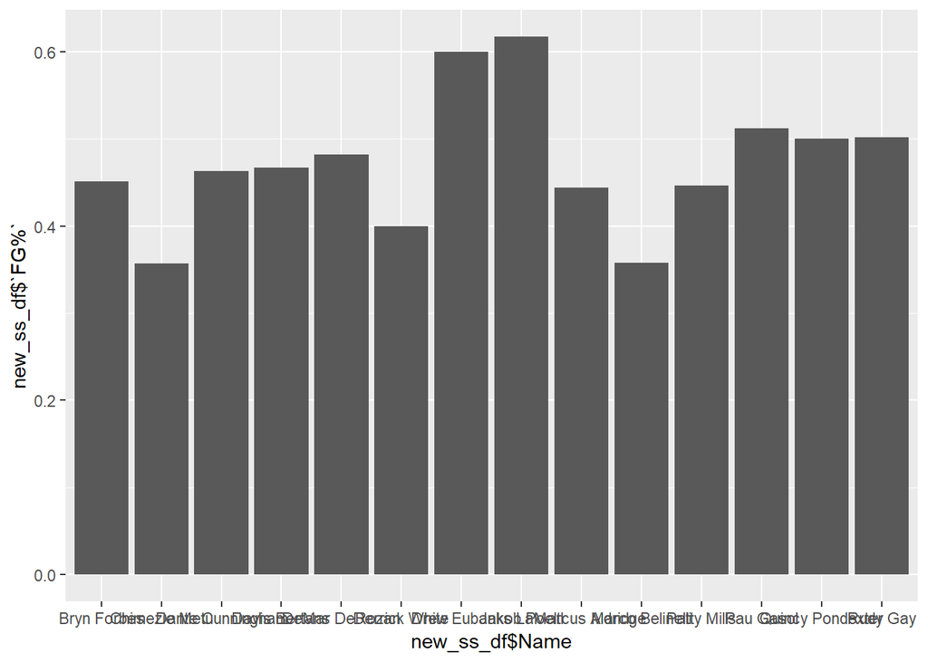

```r
ggplot(new_ss_df, aes(x=new_ss_df$Name, y=new_ss_df$`FG%`)) + geom_bar(position="dodge",stat="identity")
```

## Question 2D-1:

Informative Title, centered

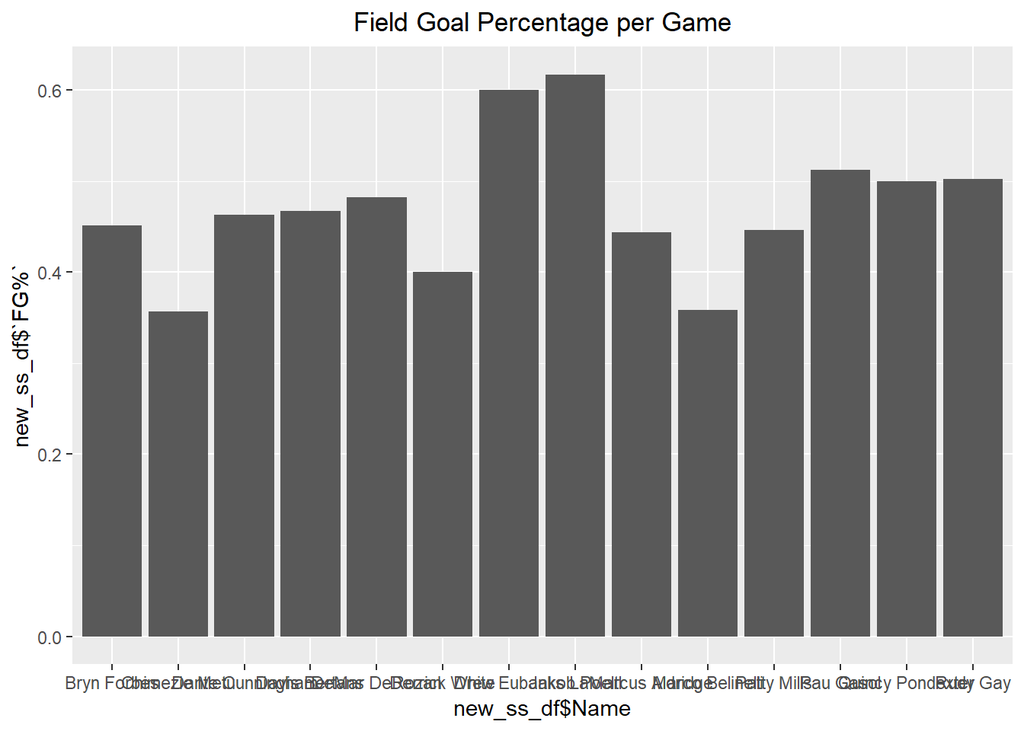

```r
# Adding: + ggtitle("Field Goal Percentage per Game") + theme(plot.title = element_text(hjust = 0.5))
ggplot(new_ss_df, aes(x=new_ss_df$Name, y=new_ss_df$`FG%`)) + geom_bar(position="dodge",stat="identity") + ggtitle("Field Goal Percentage per Game") + theme(plot.title = element_text(hjust = 0.5))
```

## Question 2D-2:

Relevant x and y axis labels (not simply variables names!)

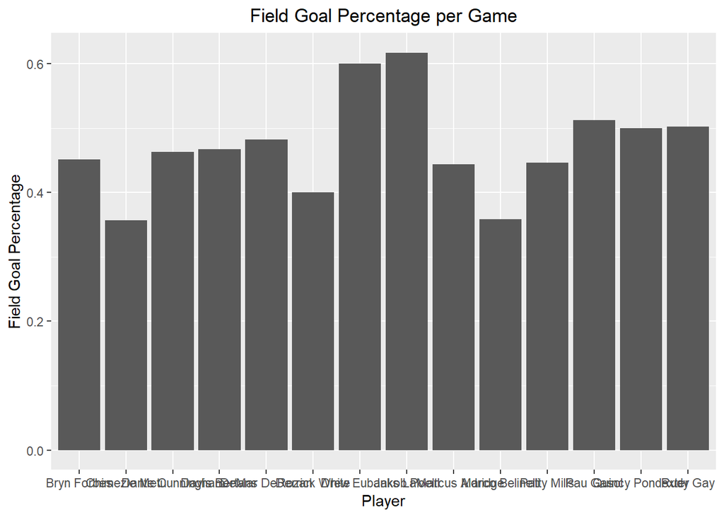

```r
# Creating variables for the x and y labels
x_label="Player"
y_label="Field Goal Percentage"
# Adding: + labs(x=x_label, y=y_label)
ggplot(new_ss_df, aes(x=new_ss_df$Name, y=new_ss_df$`FG%`)) + geom_bar(position="dodge",stat="identity") + ggtitle("Field Goal Percentage per Game") + theme(plot.title = element_text(hjust = 0.5)) + labs(x=x_label, y=y_label)
```

## Question 2D-3:

Human-readable axes with no overlap (you might have to flip x and y to fix that). Note: You do not have to convert the decimal to a percentage.

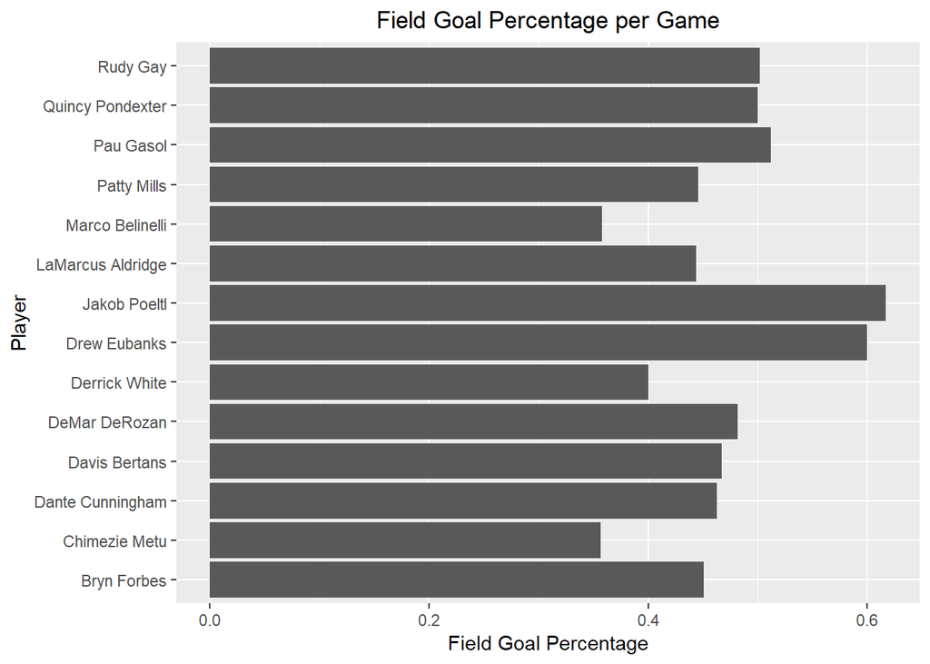

```r
# Adding: + coord_flip()
ggplot(new_ss_df, aes(x=new_ss_df$Name, y=new_ss_df$`FG%`)) + geom_bar(position="dodge",stat="identity") + ggtitle("Field Goal Percentage per Game") + theme(plot.title = element_text(hjust = 0.5)) + labs(x=x_label, y=y_label) + coord_flip()
```

## Question 2D-4:

Color the columns by the team member’s position (so, all PF’s should have the same color, etc.)

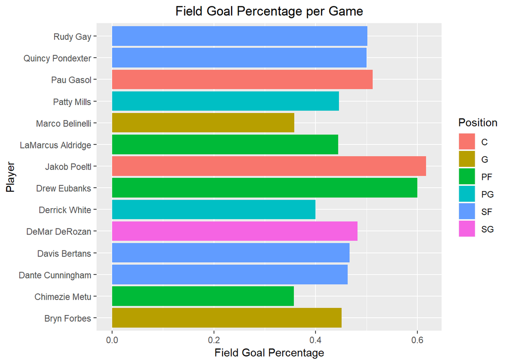

```r
# Adding: fill=factor(new_ss_df$Position)
# to the 'aes' section
# Adding: fill=fill_label
# to the 'labs' section
# Creating the fill_label
fill_label="Position"
ggplot(new_ss_df, aes(x=new_ss_df$Name, y=new_ss_df$`FG%`, fill=factor(new_ss_df$Position))) + geom_bar(position="dodge",stat="identity") + ggtitle("Field Goal Percentage per Game") + theme(plot.title = element_text(hjust = 0.5)) + labs(x=x_label, y=y_label, fill=fill_label) + coord_flip()
```